# Introduction

PHRM3302 Tutorial

## Objectives, Set-up and Expectations

### Course aim

Identify and discuss the relationship between society and health. Develop an understanding of the ways in which social factors can influence health and the quality use of medicines.

### Objectives

1. Describe the aims, methods and theoretical perspectives of the social sciences.
2. Apply the theories and methods of the social sciences to analyse case studies relating to health, illness and healthcare.
3. Explain how our history, experience, culture, beliefs and relationships can impact medication safety and effectiveness, medication adherence and health outcomes.
4. Understand the ways in which culture informs patient centred and personalised care to Aboriginal and Torres Strait Islander peoples and other Australians of diverse cultural and linguistic backgrounds.
5. Evaluate how local and global initiatives (e.g. Royal Commission findings, Sustainable Development Goals) seek to improve health outcomes and the provision of healthcare.
6. Demonstrate thinking skills individually and within a group by identifying and evaluating arguments; recognising and considering alternative points of view, and clearly expressing and justifying a position.

### Course set-up

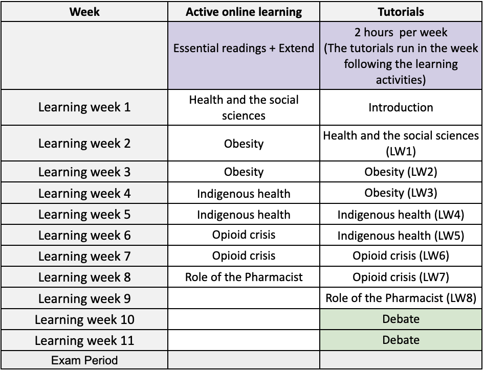

- PHRM3302 is a 2-unit course. You should expect to spend approximately 10 hours a week on the course

| Components | Hours/week (approx) |
| --- | --- |
| Essential reading + Active online learning (UQ Extend) | 4–6 |
| Tutorials | 2 |
| Assessment | 2–4 |

### Approaching the course

- The course is topic-based
- Each week you are provided with one or two **essential readings**. These are linked to the engagement tasks and are a core part of the learning activities for the week.
- Complete the activities and engagement tasks *before the tutorial*: they are set up to guide you through the course and prepare you for assessment
- Attend tutorials in person (tutorials are not recorded)

### Timetable

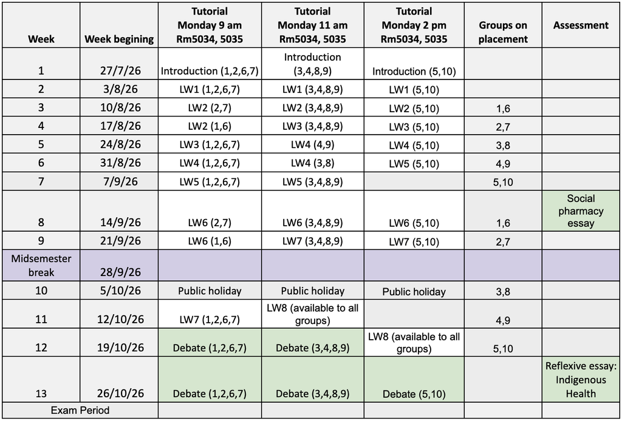

### Course Resources

- Blackboard
- Course profile
- UQ Extend
- Ed Discussion Board
- [Reading List](https://uq.rl.talis.com/courses/phrm3302.html)

### Expectations

- Complete the essential readings and engagement tasks prior to the tutorial
- Engage in tutorial discussions
- Recognise that people will hold different positions on some topics, some of which you might disagree with. As much possible engage and seek to understand the reasons for different positions.

### What you can expect from the course

- Clarity about learning objectives and assessment. If something is not clear post your question to the course discussion board
- Tutorials have a worksheet, but are not recorded
- The course is set up to provide feedback and help you to progressively develop skills
- There will be some time in tutorials to prepare for the debate assessment

## Assessment

### Overview

| Assessment | Due | Weight |
| --- | --- | --- |
| Engagement tasks (prior to tutorials ) | LW1-LW8 | 10% |
| Social Pharmacy Essay | Week 8 | 30% |
| Reflexive essay: Indigenous health | Week 13 | 20% |
| Debate (in class + submission) | W12 or W13 | 40% |

To pass PHRM3302 you need to achieve a **total mark $\ge$ 50%**

### Engagement tasks

- Linked to essential readings and active online learning (Extend)
- Complete as you work through the learning activities for the week
- Submit via Blackboard by Friday 3 pm prior to the tutorial for the learning week on Monday
- Each task is worth up to 2% (to a maximum of 10%)
- No extensions, no marks for late submission (you have 8 engagement tasks to complete; 5 x 2% can give you full marks)
- Strictly no generative AI output (no marks)

### Social pharmacy essay

- Provide a response to a stimulus from one of the topics discussed in the course
- Essay: 1200 words
- Generative AI permitted, but take care with use (see task sheet and Blackboard)
- Due Week 8

### Reflexive essay: Indigenous health

- Write a reflexive essay on providing culturally safe care to Indigenous people and communities
- Essay component of assignment is 1000 words
- Generative AI permitted, but take care with use (see task sheet and Blackboard)
- Due Week 13 (but can be completed anytime from Week 8)

### Debate

- Engage in an in-class debate with a small group of peers on a topic in social pharmacy.
- The topic statement will be determined during tutorials.
- The debate will occur in groups of 2 x 3 students. One group of students will argue in the affirmative and the other in the negative.
- Will take place in the tutorial time in Week 12 and Week 13 (depending on your group)

### Guidance on use of artificial intelligence

- You are permitted to use AI in the assignments
- Take care to know the difference between **appropriate** and **inappropriate** use
- You need to acknowledge how you used AI *and* provide a link to a version of your assignment that provides a complete version history

See guidance on Blackboard and [AI student hub](https://web.library.uq.edu.au/study-and-learning-support/ai-student-hub).

It is your responsibility to ensure that you provide a link to your complete version history that can be accessed by the person marking your assignment.

Use a Word document saved in your OneDrive account to complete the assignment. Ensure you are using your University OneDrive account (rather than a personal account or an old school account).

## In class discussion

### Accountable talk

1. Accountable to the learning community
2. Accountable to knowledge
3. Accountable to reasoning

### Accountable to the learning community

This is about learning together, being good to each other and having respectful and critical discussions that move forward.

Watch (and discuss): [Jama Shelton, Safe spaces are not enough (to change the world)](https://youtu.be/haUz1PMseyM?si=Q4Qjzzy8Y_Eu6Q5E)

### Accountable to reasoning

- Cognitive skill: evaluate, analyse, justify, explain (also: interpret, infer, reflect)
- Values of inquiry (see resource): clarity, accuracy, precision, depth, breadth, relevance, significance, coherence
- [Argument mapping](https://reasons.io/learn/01) (we discussed this in PHRM3301)

## Activities

### Alex Bellos, *Think twice*

1. There are two ducks in front of two ducks, two ducks behind two ducks and two ducks in between. What is the minimum number of ducks?
2. Image you are travelling around Dutton Park Campus (you can travel over water and through obstacles). If the radius is 1 km, you will travel approximately 6.28 km. If the radius is 100 km, you will travel approximately 628 km. If the radius is 10 000 km, will you travel approximately 62 800 km? (The circumference of a circle is $2 \times \pi \times r$)

### How should nicotine vaping products be regulated?

> Nicotine vaping products should *only* be available on prescription or as pharmacist-only products
1. Split into groups of 4–6. Each group further split into Group A (2 to 3 students) and Group B (2 to 3 students).
2. Group A will *affirm* the proposition, Group B will *negate* the proposition.
3. Develop your arguments within your small group (Group A, Group B) 5–10 minutes
4. Group A presents their arguments to Group B (5 minutes)
5. Group B presents their arguments to Group A (5 minutes)
6. Discuss and develop (if possible) an overall position among the two groups

Provide an argument map for your group’s position